# Question

If $(x+n)$ is a factor of the polynomial below, and $n$ is an integer, then what is the value of $n$?

$${3}x^{2}-{37}x+{90}$$

# Solution

$${3}x^{2}-{37}x+{90}$$

You’ll want to factor the expression.

Set up a box with what you know… Notice that the leading (quadratic) coefficient, $a=3$, is prime. This allows us to be more confident in how this expression factors.

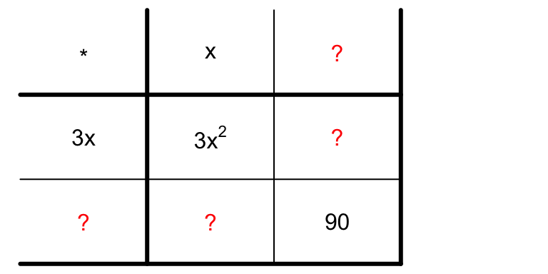

You can get this by guessing and checking. To make a smart guess, find a pair of integers that multiply to get $90$, and use those…

Eventually, because $(-10)\cdot(-9)=90$, you will guess the following factored form:

$$({3}x-{10})\cdot(x-{9})$$

And you will check it with a box to see that it works.

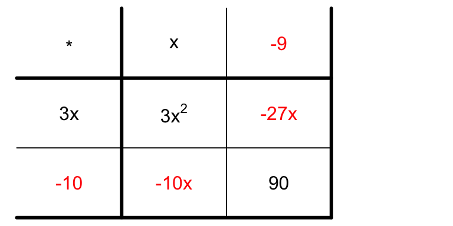

$${3}x^{2}-{27}x-{10}x+{90}$$

Combine like terms.

$${3}x^{2}-{37}x+{90}$$

So it worked! (Because it matches the given standard-form expression.) Thus, in factored form, the expression is:

$$({3}x-{10})\cdot(x-{9})$$

The problem asked for the constant of the second factor, because it asked for the constant of the factor with a linear coefficient of 1.

$$n=-9$$

# Meta-information

extype: num exsolution: -9 exname: factor_quadratic